# RestaurantsViolation (1)

**Objective:** **Explore the possibility of building a minimally viable product (MVP) model to predict the likelihood of a restaurant receiving a Critical violation.**

**The following jupyter notebook contains the code for modeling and step-by step explaination for each step**

Packages needed for modeling

- Install **Pandas Profiling** package for initial Data Exploration
- Install **Category Encoders** package for performing target encoding of categorical variable

### 0) Install & import necessary packages

```python
!pip install pandas-profiling[notebook]
! pip install category_encoders
```

```
  WARNING: pandas-profiling 1.4.1 does not provide the extra 'notebook'
```

Import all necessary packages for the model building

```python
import numpy as np
import pandas as pd
from pandas_profiling import ProfileReport
from sklearn.model_selection import train_test_split
from matplotlib import pyplot as plt
import category_encoders as ce
from sklearn.preprocessing import MinMaxScaler
from sklearn.model_selection import GridSearchCV
from sklearn.ensemble import RandomForestClassifier
from sklearn.metrics import brier_score_loss
from matplotlib import pyplot
from IPython.core.display import display, HTML
from sklearn.metrics import log_loss
```

```python
from google.colab import drive
drive.mount('/content/drive')
```

[output not shown]

### **1) Read the data from the source**

**Function Name**: read_data

**Parameter**: PATH: Path where the data file is stored. I have stored the data file on Google Drive and my PATH variable contains the path of the file on Google Drive

**Function Description**: Read the excel from the path

```python
def read_data(PATH):
  data = pd.read_excel(PATH)
  return data
```

```python
#Read the data from the path
PATH="/content/drive/My Drive/Restaurants_Inspection/RESTAURANT_INSPECTIONS_PROCESSED.xlsx"
data=read_data(PATH)
```

### **2) Initial Data Exploration**

In order to do a quick thorough exploration of the dataset and identify patterns in them I am using the **pandas profiling package** that generates an exhaustive report of all the features of the dataset

Overview

Dataset info

| Number of variables | 36 |
| --- | --- |
| Number of observations | 31419 |
| Total Missing (%) | 2.2% |
| Total size in memory | 8.6 MiB |
| Average record size in memory | 288.0 B |

Variables types

| Numeric | 6 |
| --- | --- |
| Categorical | 25 |
| Boolean | 0 |
| Date | 1 |
| Text (Unique) | 1 |
| Rejected | 3 |
| Unsupported | 0 |

Warnings

- `RESTAURANT_PERMIT_NUMBER` has a high cardinality: 11871 distinct values Warning

- `RESTAURANT_NAME` has a high cardinality: 11425 distinct values Warning

- `RESTAURANT_LOCATION` has a high cardinality: 6254 distinct values Warning

- `ADDRESS` has a high cardinality: 5961 distinct values Warning

- `STATE` has constant value Nevada Rejected

- `ZIP` has a high cardinality: 2897 distinct values Warning

- `CURRENT_DEMERITS` has 8128 / 25.9% zeros Zeros

- `DATE_CURRENT` has a high cardinality: 1604 distinct values Warning

- `INSPECTION_DATE_RAW` has a high cardinality: 2117 distinct values Warning

- `INSPECTION_TIME` has a high cardinality: 26991 distinct values Warning

- `EMPLOYEE_ID` has a high cardinality: 158 distinct values Warning

- `PERMIT_STATUS` has 24500 / 78.0% missing values Missing

- `VIOLATIONS_RAW` has a high cardinality: 22371 distinct values Warning

- `RECORD_UPDATED` has a high cardinality: 9921 distinct values Warning

- `LAT_LONG_RAW` has a high cardinality: 5831 distinct values Warning

- `LOCATION_LONGITUDE` is highly skewed (γ1 = 58.53) Skewed

- `SECOND_VIOLATION` is highly correlated with `FIRST_VIOLATION` (ρ = 0.99692) Rejected

- `THIRD_VIOLATION` is highly correlated with `SECOND_VIOLATION` (ρ = 0.98679) Rejected

- `FIRST_VIOLATION_DS` has a high cardinality: 68 distinct values Warning

- `SECOND_VIOLATION_DS` has a high cardinality: 74 distinct values Warning

- `THIRD_VIOLATION_DS` has a high cardinality: 82 distinct values Warning

Variables

RESTAURANT_SERIAL_NUMBER  
Categorical, Unique

| First 3 values |
| --- |
| DA1025348 |
| DA1669857 |
| DA1137312 |

| Last 3 values |
| --- |
| DA1463794 |
| DA1463177 |
| DA1037811 |

Toggle details

First 10 values

| Value | Count | Frequency (%) |  |
| --- | --- | --- | --- |
| DA0001131 | 1 | 0.0% |  |
| DA0001173 | 1 | 0.0% |  |
| DA0001760 | 1 | 0.0% |  |
| DA0001773 | 1 | 0.0% |  |
| DA0001822 | 1 | 0.0% |  |

Last 10 values

| Value | Count | Frequency (%) |  |
| --- | --- | --- | --- |
| DAZZEIZJM | 1 | 0.0% |  |
| DAZZSE0YW | 1 | 0.0% |  |
| DAZZVFR5I | 1 | 0.0% |  |
| DAZZXYCCX | 1 | 0.0% |  |
| DAZZYV0DF | 1 | 0.0% |  |

RESTAURANT_PERMIT_NUMBER  
Categorical

| Distinct count | 11871 |
| --- | --- |
| Unique (%) | 37.8% |
| Missing (%) | 0.0% |
| Missing (n) | 0 |

| PR0019925 | 17 |
| --- | --- |
| PR0012160 | 17 |
| PR0019729 | 16 |
| Other values (11868) | 31369 |

Toggle details

| Value | Count | Frequency (%) |  |
| --- | --- | --- | --- |
| PR0019925 | 17 | 0.1% |  |
| PR0012160 | 17 | 0.1% |  |
| PR0019729 | 16 | 0.1% |  |
| PR0008421 | 15 | 0.0% |  |
| PR0015707 | 15 | 0.0% |  |
| PR0020660 | 15 | 0.0% |  |
| PR0018995 | 15 | 0.0% |  |
| PR0009870 | 14 | 0.0% |  |
| PR0016101 | 14 | 0.0% |  |
| PR0017991 | 14 | 0.0% |  |
| Other values (11861) | 31267 | 99.5% |  |

RESTAURANT_NAME  
Categorical

| Distinct count | 11425 |
| --- | --- |
| Unique (%) | 36.4% |
| Missing (%) | 0.0% |
| Missing (n) | 1 |

| Robertos Taco Shop | 200 |
| --- | --- |
| Dairy Queen | 53 |
| Capriottis Sandwich Shop | 47 |
| Other values (11421) | 31118 |

Toggle details

| Value | Count | Frequency (%) |  |
| --- | --- | --- | --- |
| Robertos Taco Shop | 200 | 0.6% |  |
| Dairy Queen | 53 | 0.2% |  |
| Capriottis Sandwich Shop | 47 | 0.1% |  |
| Teriyaki Madness | 39 | 0.1% |  |
| PTS to Go | 38 | 0.1% |  |
| CAPRIOTTIS SANDWICH SHOP | 35 | 0.1% |  |
| Little Dumpling | 31 | 0.1% |  |
| IHOP | 29 | 0.1% |  |
| China a Go Go | 29 | 0.1% |  |
| Baja Fresh | 27 | 0.1% |  |
| Other values (11414) | 30890 | 98.3% |  |

RESTAURANT_LOCATION  
Categorical

| Distinct count | 6254 |
| --- | --- |
| Unique (%) | 19.9% |
| Missing (%) | 0.0% |
| Missing (n) | 3 |

| MIRAGE HOTEL & CASINO | 237 |
| --- | --- |
| CAESARS PALACE HOTEL & CASINO | 226 |
| ARIA HOTEL & CASINO | 203 |
| Other values (6250) | 30750 |

Toggle details

| Value | Count | Frequency (%) |  |
| --- | --- | --- | --- |
| MIRAGE HOTEL & CASINO | 237 | 0.8% |  |
| CAESARS PALACE HOTEL & CASINO | 226 | 0.7% |  |
| ARIA HOTEL & CASINO | 203 | 0.6% |  |
| MGM GRAND HOTEL & CASINO | 199 | 0.6% |  |
| PARIS HOTEL & CASINO | 191 | 0.6% |  |
| Robertos Taco Shop | 180 | 0.6% |  |
| MANDALAY BAY HOTEL & CASINO | 176 | 0.6% |  |
| BELLAGIO HOTEL & CASINO | 174 | 0.6% |  |
| HARRAHS LV HOTEL & CASINO | 165 | 0.5% |  |
| COSMOPOLITAN RESORT & CASINO | 164 | 0.5% |  |
| Other values (6243) | 29501 | 93.9% |  |

RESTAURANT_CATEGORY  
Categorical

| Distinct count | 29 |
| --- | --- |
| Unique (%) | 0.1% |
| Missing (%) | 0.0% |
| Missing (n) | 0 |

| Restaurant | 18941 |
| --- | --- |
| Bar / Tavern | 4704 |
| Snack Bar | 2608 |
| Other values (26) | 5166 |

Toggle details

| Value | Count | Frequency (%) |  |
| --- | --- | --- | --- |
| Restaurant | 18941 | 60.3% |  |
| Bar / Tavern | 4704 | 15.0% |  |
| Snack Bar | 2608 | 8.3% |  |
| Special Kitchen | 2313 | 7.4% |  |
| Buffet | 447 | 1.4% |  |
| Portable Unit | 389 | 1.2% |  |
| Pantry | 339 | 1.1% |  |
| Meat/Poultry/Seafood | 302 | 1.0% |  |
| Food Trucks / Mobile Vendor | 202 | 0.6% |  |
| Kitchen Bakery | 145 | 0.5% |  |
| Other values (19) | 1029 | 3.3% |  |

ADDRESS  
Categorical

| Distinct count | 5961 |
| --- | --- |
| Unique (%) | 19.0% |
| Missing (%) | 0.0% |
| Missing (n) | 11 |

| 3400 S Las Vegas Blvd | 274 |
| --- | --- |
| 3799 S Las Vegas Blvd | 266 |
| 3950 S Las Vegas Blvd | 260 |
| Other values (5957) | 30608 |

Toggle details

| Value | Count | Frequency (%) |  |
| --- | --- | --- | --- |
| 3400 S Las Vegas Blvd | 274 | 0.9% |  |
| 3799 S Las Vegas Blvd | 266 | 0.8% |  |
| 3950 S Las Vegas Blvd | 260 | 0.8% |  |
| 3355 S Las Vegas Blvd | 244 | 0.8% |  |
| 3570 S Las Vegas Blvd | 233 | 0.7% |  |
| 3655 S Las Vegas Blvd | 223 | 0.7% |  |
| 3730 S Las Vegas Blvd | 203 | 0.6% |  |
| 3475 S Las Vegas Blvd | 192 | 0.6% |  |
| 3708 S Las Vegas Blvd | 177 | 0.6% |  |
| 3600 S Las Vegas Blvd | 174 | 0.6% |  |
| Other values (5950) | 29162 | 92.8% |  |

CITY  
Categorical

| Distinct count | 21 |
| --- | --- |
| Unique (%) | 0.1% |
| Missing (%) | 0.0% |
| Missing (n) | 8 |

| Las Vegas | 25186 |
| --- | --- |
| Henderson | 3011 |
| North Las Vegas | 1897 |
| Other values (17) | 1317 |

Toggle details

| Value | Count | Frequency (%) |  |
| --- | --- | --- | --- |
| Las Vegas | 25186 | 80.2% |  |
| Henderson | 3011 | 9.6% |  |
| North Las Vegas | 1897 | 6.0% |  |
| Laughlin | 396 | 1.3% |  |
| Mesquite | 320 | 1.0% |  |
| Boulder City | 272 | 0.9% |  |
| Primm | 197 | 0.6% |  |
| Searchlight | 24 | 0.1% |  |
| Overton | 21 | 0.1% |  |
| Indian Springs | 20 | 0.1% |  |
| Other values (10) | 67 | 0.2% |  |

STATE  
Constant

*This variable is constant and should be ignored for analysis*

| Constant value | Nevada |
| --- | --- |

ZIP  
Categorical

| Distinct count | 2897 |
| --- | --- |
| Unique (%) | 9.2% |
| Missing (%) | 0.0% |
| Missing (n) | 8 |

| 89109 | 929 |
| --- | --- |
| 89102 | 400 |
| 89119 | 358 |
| Other values (2893) | 29724 |

Toggle details

| Value | Count | Frequency (%) |  |
| --- | --- | --- | --- |
| 89109 | 929 | 3.0% |  |
| 89102 | 400 | 1.3% |  |
| 89119 | 358 | 1.1% |  |
| 89101 | 328 | 1.0% |  |
| 89109-8941 | 320 | 1.0% |  |
| 89146 | 312 | 1.0% |  |
| 89130 | 300 | 1.0% |  |
| 89103 | 275 | 0.9% |  |
| 89109-8923 | 274 | 0.9% |  |
| 89109-4319 | 263 | 0.8% |  |
| Other values (2886) | 27652 | 88.0% |  |

CURRENT_DEMERITS  
Numeric

| Distinct count | 49 |
| --- | --- |
| Unique (%) | 0.2% |
| Missing (%) | 0.0% |
| Missing (n) | 0 |
| Infinite (%) | 0.0% |
| Infinite (n) | 0 |

| Mean | 5.0367 |
| --- | --- |
| Minimum | 0 |
| Maximum | 100 |
| Zeros (%) | 25.9% |

Toggle details

**Statistics**

Quantile statistics

| Minimum | 0 |
| --- | --- |
| 5-th percentile | 0 |
| Q1 | 0 |
| Median | 5 |
| Q3 | 8 |
| 95-th percentile | 10 |
| Maximum | 100 |
| Range | 100 |
| Interquartile range | 8 |

Descriptive statistics

| Standard deviation | 5.0503 |
| --- | --- |
| Coef of variation | 1.0027 |
| Kurtosis | 67.905 |
| Mean | 5.0367 |
| MAD | 3.4631 |
| Skewness | 5.0027 |
| Sum | 158247 |
| Variance | 25.505 |
| Memory size | 245.6 KiB |

**Histogram**

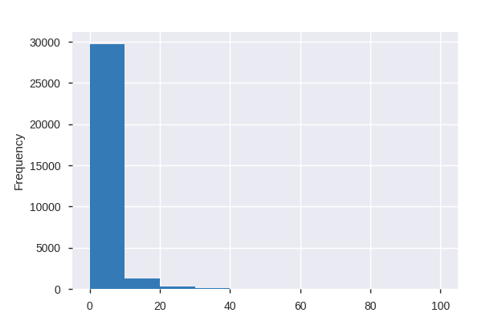

**Common Values**

| Value | Count | Frequency (%) |  |
| --- | --- | --- | --- |
| 0 | 8128 | 25.9% |  |
| 3 | 6213 | 19.8% |  |
| 8 | 5062 | 16.1% |  |
| 6 | 4393 | 14.0% |  |
| 9 | 3828 | 12.2% |  |
| 5 | 1557 | 5.0% |  |
| 10 | 926 | 2.9% |  |
| 7 | 213 | 0.7% |  |
| 4 | 130 | 0.4% |  |
| 19 | 120 | 0.4% |  |
| Other values (39) | 849 | 2.7% |  |

**Extreme Values**

Minimum 5 values

| Value | Count | Frequency (%) |  |
| --- | --- | --- | --- |
| 0 | 8128 | 25.9% |  |
| 1 | 95 | 0.3% |  |
| 2 | 78 | 0.2% |  |
| 3 | 6213 | 19.8% |  |
| 4 | 130 | 0.4% |  |

Maximum 5 values

| Value | Count | Frequency (%) |  |
| --- | --- | --- | --- |
| 51 | 8 | 0.0% |  |
| 61 | 3 | 0.0% |  |
| 88 | 2 | 0.0% |  |
| 89 | 2 | 0.0% |  |
| 100 | 12 | 0.0% |  |

CURRENT_GRADE  
Categorical

| Distinct count | 7 |
| --- | --- |
| Unique (%) | 0.0% |
| Missing (%) | 0.0% |
| Missing (n) | 9 |

| A | 30523 |
| --- | --- |
| B | 437 |
| C | 210 |
| Other values (3) | 240 |

Toggle details

| Value | Count | Frequency (%) |  |
| --- | --- | --- | --- |
| A | 30523 | 97.1% |  |
| B | 437 | 1.4% |  |
| C | 210 | 0.7% |  |
| X | 136 | 0.4% |  |
| O | 76 | 0.2% |  |
| N | 28 | 0.1% |  |
| (Missing) | 9 | 0.0% |  |

DATE_CURRENT  
Categorical

| Distinct count | 1604 |
| --- | --- |
| Unique (%) | 5.1% |
| Missing (%) | 0.0% |
| Missing (n) | 0 |

| 01/12/2017 12:00:00 AM | 253 |
| --- | --- |
| 03/15/2017 12:00:00 AM | 245 |
| 03/16/2017 12:00:00 AM | 234 |
| Other values (1601) | 30687 |

Toggle details

| Value | Count | Frequency (%) |  |
| --- | --- | --- | --- |
| 01/12/2017 12:00:00 AM | 253 | 0.8% |  |
| 03/15/2017 12:00:00 AM | 245 | 0.8% |  |
| 03/16/2017 12:00:00 AM | 234 | 0.7% |  |
| 01/19/2017 12:00:00 AM | 231 | 0.7% |  |
| 05/25/2017 12:00:00 AM | 222 | 0.7% |  |
| 03/07/2017 12:00:00 AM | 210 | 0.7% |  |
| 01/31/2017 12:00:00 AM | 210 | 0.7% |  |
| 05/18/2017 12:00:00 AM | 209 | 0.7% |  |
| 03/29/2017 12:00:00 AM | 207 | 0.7% |  |
| 01/24/2017 12:00:00 AM | 203 | 0.6% |  |
| Other values (1594) | 29195 | 92.9% |  |

INSPECTION_DATE  
Date

| Distinct count | 2117 |
| --- | --- |
| Unique (%) | 6.7% |
| Missing (%) | 0.0% |
| Missing (n) | 0 |
| Infinite (%) | 0.0% |
| Infinite (n) | 0 |

| Minimum | 2010-01-02 00:00:00 |
| --- | --- |
| Maximum | 2017-10-11 00:00:00 |

Toggle details

[figure not shown]

INSPECTION_DATE_RAW  
Categorical

| Distinct count | 2117 |
| --- | --- |
| Unique (%) | 6.7% |
| Missing (%) | 0.0% |
| Missing (n) | 0 |

| 07/20/2012 12:00:00 AM | 70 |
| --- | --- |
| 02/22/2012 12:00:00 AM | 66 |
| 10/29/2012 12:00:00 AM | 65 |
| Other values (2114) | 31218 |

Toggle details

| Value | Count | Frequency (%) |  |
| --- | --- | --- | --- |
| 07/20/2012 12:00:00 AM | 70 | 0.2% |  |
| 02/22/2012 12:00:00 AM | 66 | 0.2% |  |
| 10/29/2012 12:00:00 AM | 65 | 0.2% |  |
| 07/24/2012 12:00:00 AM | 64 | 0.2% |  |
| 10/30/2012 12:00:00 AM | 64 | 0.2% |  |
| 08/08/2012 12:00:00 AM | 64 | 0.2% |  |
| 07/25/2012 12:00:00 AM | 63 | 0.2% |  |
| 06/21/2012 12:00:00 AM | 63 | 0.2% |  |
| 07/10/2012 12:00:00 AM | 61 | 0.2% |  |
| 08/07/2012 12:00:00 AM | 61 | 0.2% |  |
| Other values (2107) | 30778 | 98.0% |  |

INSPECTION_TIME  
Categorical

| Distinct count | 26991 |
| --- | --- |
| Unique (%) | 85.9% |
| Missing (%) | 0.0% |
| Missing (n) | 7 |

| 01/01/1900 12:00:00 AM | 10 |
| --- | --- |
| 06/14/2012 08:00:00 AM | 9 |
| 07/12/2012 08:00:00 AM | 8 |
| Other values (26987) | 31385 |

Toggle details

| Value | Count | Frequency (%) |  |
| --- | --- | --- | --- |
| 01/01/1900 12:00:00 AM | 10 | 0.0% |  |
| 06/14/2012 08:00:00 AM | 9 | 0.0% |  |
| 07/12/2012 08:00:00 AM | 8 | 0.0% |  |
| 02/08/2012 08:00:00 AM | 7 | 0.0% |  |
| 08/10/2012 08:00:00 AM | 6 | 0.0% |  |
| 03/20/2012 08:00:00 AM | 6 | 0.0% |  |
| 03/22/2012 08:00:00 AM | 6 | 0.0% |  |
| 09/26/2012 08:00:00 AM | 6 | 0.0% |  |
| 07/25/2012 03:45:00 PM | 5 | 0.0% |  |
| 07/05/2012 08:00:00 AM | 5 | 0.0% |  |
| Other values (26980) | 31344 | 99.8% |  |
| (Missing) | 7 | 0.0% |  |

EMPLOYEE_ID  
Categorical

| Distinct count | 158 |
| --- | --- |
| Unique (%) | 0.5% |
| Missing (%) | 0.0% |
| Missing (n) | 0 |

| EE7000772 | 1265 |
| --- | --- |
| EE7000803 | 1090 |
| EE7000327 | 1062 |
| Other values (155) | 28002 |

Toggle details

| Value | Count | Frequency (%) |  |
| --- | --- | --- | --- |
| EE7000772 | 1265 | 4.0% |  |
| EE7000803 | 1090 | 3.5% |  |
| EE7000327 | 1062 | 3.4% |  |
| EE7000443 | 939 | 3.0% |  |
| EE7001010 | 846 | 2.7% |  |
| EE7000594 | 761 | 2.4% |  |
| EE7000487 | 696 | 2.2% |  |
| EE7000860 | 693 | 2.2% |  |
| EE7000802 | 663 | 2.1% |  |
| EE7000390 | 631 | 2.0% |  |
| Other values (148) | 22773 | 72.5% |  |

INSPECTION_TYPE  
Categorical

| Distinct count | 3 |
| --- | --- |
| Unique (%) | 0.0% |
| Missing (%) | 0.0% |
| Missing (n) | 0 |

| Routine Inspection | 29652 |
| --- | --- |
| Re-inspection | 1766 |
| Epidemiological Investigation | 1 |

Toggle details

| Value | Count | Frequency (%) |  |
| --- | --- | --- | --- |
| Routine Inspection | 29652 | 94.4% |  |
| Re-inspection | 1766 | 5.6% |  |
| Epidemiological Investigation | 1 | 0.0% |  |

INSPECTION_DEMERITS  
Numeric

| Distinct count | 69 |
| --- | --- |
| Unique (%) | 0.2% |
| Missing (%) | 0.0% |
| Missing (n) | 0 |
| Infinite (%) | 0.0% |
| Infinite (n) | 0 |

| Mean | 13.591 |
| --- | --- |
| Minimum | 0 |
| Maximum | 89 |
| Zeros (%) | 0.0% |

Toggle details

**Statistics**

Quantile statistics

| Minimum | 0 |
| --- | --- |
| 5-th percentile | 4 |
| Q1 | 8 |
| Median | 10 |
| Q3 | 19 |
| 95-th percentile | 31 |
| Maximum | 89 |
| Range | 89 |
| Interquartile range | 11 |

Descriptive statistics

| Standard deviation | 8.478 |
| --- | --- |
| Coef of variation | 0.62382 |
| Kurtosis | 3.2875 |
| Mean | 13.591 |
| MAD | 6.6795 |
| Skewness | 1.5015 |
| Sum | 427002 |
| Variance | 71.877 |
| Memory size | 245.6 KiB |

**Histogram**

[figure not shown]

**Common Values**

| Value | Count | Frequency (%) |  |
| --- | --- | --- | --- |
| 10 | 3962 | 12.6% |  |
| 9 | 3738 | 11.9% |  |
| 19 | 2344 | 7.5% |  |
| 20 | 2275 | 7.2% |  |
| 7 | 2251 | 7.2% |  |
| 8 | 2129 | 6.8% |  |
| 5 | 1853 | 5.9% |  |
| 6 | 1612 | 5.1% |  |
| 17 | 1594 | 5.1% |  |
| 3 | 1246 | 4.0% |  |
| Other values (59) | 8415 | 26.8% |  |

**Extreme Values**

Minimum 5 values

| Value | Count | Frequency (%) |  |
| --- | --- | --- | --- |
| 0 | 14 | 0.0% |  |
| 3 | 1246 | 4.0% |  |
| 4 | 416 | 1.3% |  |
| 5 | 1853 | 5.9% |  |
| 6 | 1612 | 5.1% |  |

Maximum 5 values

| Value | Count | Frequency (%) |  |
| --- | --- | --- | --- |
| 70 | 2 | 0.0% |  |
| 77 | 1 | 0.0% |  |
| 82 | 1 | 0.0% |  |
| 86 | 2 | 0.0% |  |
| 89 | 1 | 0.0% |  |

INSPECTION_GRADE  
Categorical

| Distinct count | 9 |
| --- | --- |
| Unique (%) | 0.0% |
| Missing (%) | 0.2% |
| Missing (n) | 78 |

| A | 16645 |
| --- | --- |
| B | 10147 |
| C | 3340 |
| Other values (5) | 1209 |

Toggle details

| Value | Count | Frequency (%) |  |
| --- | --- | --- | --- |
| A | 16645 | 53.0% |  |
| B | 10147 | 32.3% |  |
| C | 3340 | 10.6% |  |
| X | 846 | 2.7% |  |
| P | 279 | 0.9% |  |
| O | 68 | 0.2% |  |
| a | 15 | 0.0% |  |
| N | 1 | 0.0% |  |
| (Missing) | 78 | 0.2% |  |

PERMIT_STATUS  
Categorical

| Distinct count | 7 |
| --- | --- |
| Unique (%) | 0.0% |
| Missing (%) | 78.0% |
| Missing (n) | 24500 |

| A | 3258 |
| --- | --- |
| B | 2396 |
| C | 780 |
| Other values (3) | 485 |
| (Missing) | 24500 |

Toggle details

| Value | Count | Frequency (%) |  |
| --- | --- | --- | --- |
| A | 3258 | 10.4% |  |
| B | 2396 | 7.6% |  |
| C | 780 | 2.5% |  |
| PASS | 275 | 0.9% |  |
| CLOSED | 194 | 0.6% |  |
| APPROVED | 16 | 0.1% |  |
| (Missing) | 24500 | 78.0% |  |

INSPECTION_RESULT  
Categorical

| Distinct count | 18 |
| --- | --- |
| Unique (%) | 0.1% |
| Missing (%) | 0.0% |
| Missing (n) | 0 |

| Compliant | 16853 |
| --- | --- |
| B Downgrade | 10025 |
| C Downgrade | 3322 |
| Other values (15) | 1219 |

Toggle details

| Value | Count | Frequency (%) |  |
| --- | --- | --- | --- |
| Compliant | 16853 | 53.6% |  |
| B Downgrade | 10025 | 31.9% |  |
| C Downgrade | 3322 | 10.6% |  |
| Closed with Fees | 810 | 2.6% |  |
| A Grade | 291 | 0.9% |  |
| Approved | 68 | 0.2% |  |
| Closed without Fees | 27 | 0.1% |  |
| Follow Up Required | 5 | 0.0% |  |
| Compliance Schedule | 3 | 0.0% |  |
| Complaint Invalid/Unsubstantiated | 3 | 0.0% |  |
| Other values (8) | 12 | 0.0% |  |

VIOLATIONS_RAW  
Categorical

| Distinct count | 22371 |
| --- | --- |
| Unique (%) | 71.2% |
| Missing (%) | 0.0% |
| Missing (n) | 0 |

| 214,230,233 | 141 |
| --- | --- |
| 229,230,233 | 84 |
| 228,230,233 | 71 |
| Other values (22368) | 31123 |

Toggle details

| Value | Count | Frequency (%) |  |
| --- | --- | --- | --- |
| 214,230,233 | 141 | 0.4% |  |
| 229,230,233 | 84 | 0.3% |  |
| 228,230,233 | 71 | 0.2% |  |
| 214,215,233 | 53 | 0.2% |  |
| 225,230,233 | 48 | 0.2% |  |
| 215,230,233 | 47 | 0.1% |  |
| 211,230,233 | 44 | 0.1% |  |
| 214,229,233 | 44 | 0.1% |  |
| 14,31,36 | 43 | 0.1% |  |
| 214,215,230,233 | 40 | 0.1% |  |
| Other values (22361) | 30804 | 98.0% |  |

RECORD_UPDATED  
Categorical

| Distinct count | 9921 |
| --- | --- |
| Unique (%) | 31.6% |
| Missing (%) | 0.0% |
| Missing (n) | 0 |

| 02/21/2013 10:26:12 PM | 20513 |
| --- | --- |
| 01/06/2015 04:34:59 PM | 157 |
| 09/11/2015 04:59:03 PM | 83 |
| Other values (9918) | 10666 |

Toggle details

| Value | Count | Frequency (%) |  |
| --- | --- | --- | --- |
| 02/21/2013 10:26:12 PM | 20513 | 65.3% |  |
| 01/06/2015 04:34:59 PM | 157 | 0.5% |  |
| 09/11/2015 04:59:03 PM | 83 | 0.3% |  |
| 01/06/2015 04:35:35 PM | 71 | 0.2% |  |
| 01/06/2015 04:35:42 PM | 18 | 0.1% |  |
| 11/05/2015 01:54:54 PM | 14 | 0.0% |  |
| 04/16/2014 04:27:15 PM | 13 | 0.0% |  |
| 07/27/2011 12:19:11 PM | 13 | 0.0% |  |
| 02/20/2015 02:26:15 PM | 10 | 0.0% |  |
| 01/06/2015 04:35:51 PM | 10 | 0.0% |  |
| Other values (9911) | 10517 | 33.5% |  |

LAT_LONG_RAW  
Categorical

| Distinct count | 5831 |
| --- | --- |
| Unique (%) | 18.6% |
| Missing (%) | 0.0% |
| Missing (n) | 0 |

| (36.1161559, 115.1750576) | 241 |
| --- | --- |
| (36.1206015, 115.1768382) | 237 |
| (36.1123576, 115.1702213) | 215 |
| Other values (5828) | 30726 |

Toggle details

| Value | Count | Frequency (%) |  |
| --- | --- | --- | --- |
| (36.1161559, 115.1750576) | 241 | 0.8% |  |
| (36.1206015, 115.1768382) | 237 | 0.8% |  |
| (36.1123576, 115.1702213) | 215 | 0.7% |  |
| (36.1022507, 115.1699679) | 213 | 0.7% |  |
| (36.1073485, 115.1765836) | 203 | 0.6% |  |
| (36.1163474, 115.1723373) | 185 | 0.6% |  |
| (36.0907541, 115.1766701) | 176 | 0.6% |  |
| (36.1140649, 115.1729856) | 172 | 0.5% |  |
| (36.1193098, 115.1717702) | 172 | 0.5% |  |
| (36.1097544, 115.1738726) | 164 | 0.5% |  |
| Other values (5821) | 29441 | 93.7% |  |

LOCATION_LATITUDE  
Numeric

| Distinct count | 5709 |
| --- | --- |
| Unique (%) | 18.2% |
| Missing (%) | 0.2% |
| Missing (n) | 74 |
| Infinite (%) | 0.0% |
| Infinite (n) | 0 |

| Mean | 36.118 |
| --- | --- |
| Minimum | 35.124 |
| Maximum | 36.832 |
| Zeros (%) | 0.0% |

Toggle details

**Statistics**

Quantile statistics

| Minimum | 35.124 |
| --- | --- |
| 5-th percentile | 36.002 |
| Q1 | 36.099 |
| Median | 36.121 |
| Q3 | 36.161 |
| 95-th percentile | 36.262 |
| Maximum | 36.832 |
| Range | 1.7083 |
| Interquartile range | 0.061971 |

Descriptive statistics

| Standard deviation | 0.15271 |
| --- | --- |
| Coef of variation | 0.0042281 |
| Kurtosis | 22.512 |
| Mean | 36.118 |
| MAD | 0.070982 |
| Skewness | -2.415 |
| Sum | 1132100 |
| Variance | 0.023321 |
| Memory size | 245.6 KiB |

**Histogram**

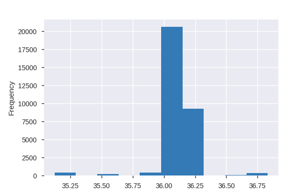

**Common Values**

| Value | Count | Frequency (%) |  |
| --- | --- | --- | --- |
| 36.1161559 | 241 | 0.8% |  |
| 36.1206015 | 237 | 0.8% |  |
| 36.1123576 | 217 | 0.7% |  |
| 36.1022507 | 213 | 0.7% |  |
| 36.1073485 | 203 | 0.6% |  |
| 36.1163474 | 187 | 0.6% |  |
| 36.0907541 | 176 | 0.6% |  |
| 36.1140649 | 172 | 0.5% |  |
| 36.1193098 | 172 | 0.5% |  |
| 36.1097544 | 164 | 0.5% |  |
| Other values (5698) | 29363 | 93.5% |  |

**Extreme Values**

Minimum 5 values

| Value | Count | Frequency (%) |  |
| --- | --- | --- | --- |
| 35.123741 | 1 | 0.0% |  |
| 35.134551 | 1 | 0.0% |  |
| 35.1352715 | 1 | 0.0% |  |
| 35.1406731 | 3 | 0.0% |  |
| 35.1422318 | 3 | 0.0% |  |

Maximum 5 values

| Value | Count | Frequency (%) |  |
| --- | --- | --- | --- |
| 36.8174382 | 4 | 0.0% |  |
| 36.820406 | 10 | 0.0% |  |
| 36.820435 | 1 | 0.0% |  |
| 36.8219663 | 2 | 0.0% |  |
| 36.832043 | 9 | 0.0% |  |

LOCATION_LONGITUDE  
Numeric

| Distinct count | 5752 |
| --- | --- |
| Unique (%) | 18.3% |
| Missing (%) | 0.0% |
| Missing (n) | 0 |
| Infinite (%) | 0.0% |
| Infinite (n) | 0 |

| Mean | -115.11 |
| --- | --- |
| Minimum | -115.68 |
| Maximum | 0 |
| Zeros (%) | 0.0% |

Toggle details

**Statistics**

Quantile statistics

| Minimum | -115.68 |
| --- | --- |
| 5-th percentile | -115.29 |
| Q1 | -115.2 |
| Median | -115.17 |
| Q3 | -115.12 |
| 95-th percentile | -114.98 |
| Maximum | 0 |
| Range | 115.68 |
| Interquartile range | 0.086177 |

Descriptive statistics

| Standard deviation | 1.9545 |
| --- | --- |
| Coef of variation | -0.016979 |
| Kurtosis | 3444.6 |
| Mean | -115.11 |
| MAD | 0.12554 |
| Skewness | 58.53 |
| Sum | -3616700 |
| Variance | 3.8199 |
| Memory size | 245.6 KiB |

**Histogram**

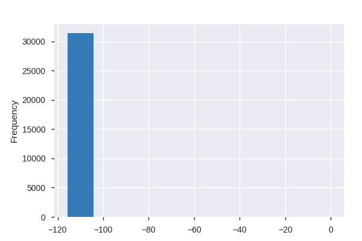

**Common Values**

| Value | Count | Frequency (%) |  |
| --- | --- | --- | --- |
| -115.1750576 | 241 | 0.8% |  |
| -115.1768382 | 237 | 0.8% |  |
| -115.1702213 | 215 | 0.7% |  |
| -115.1699679 | 213 | 0.7% |  |
| -115.1765836 | 203 | 0.6% |  |
| -115.1766701 | 196 | 0.6% |  |
| -115.1723373 | 187 | 0.6% |  |
| -115.1729856 | 172 | 0.5% |  |
| -115.1717702 | 172 | 0.5% |  |
| -115.1738726 | 164 | 0.5% |  |
| Other values (5742) | 29419 | 93.6% |  |

**Extreme Values**

Minimum 5 values

| Value | Count | Frequency (%) |  |
| --- | --- | --- | --- |
| -115.6796317 | 7 | 0.0% |  |
| -115.6726606 | 10 | 0.0% |  |
| -115.6705757 | 5 | 0.0% |  |
| -115.6704085 | 5 | 0.0% |  |
| -115.6447412 | 10 | 0.0% |  |

Maximum 5 values

| Value | Count | Frequency (%) |  |
| --- | --- | --- | --- |
| -114.0629674 | 1 | 0.0% |  |
| -114.0620809 | 5 | 0.0% |  |
| -114.061492 | 9 | 0.0% |  |
| -114.058464 | 10 | 0.0% |  |
| 0.0 | 9 | 0.0% |  |

FIRST_VIOLATION  
Numeric

| Distinct count | 68 |
| --- | --- |
| Unique (%) | 0.2% |
| Missing (%) | 0.0% |
| Missing (n) | 0 |
| Infinite (%) | 0.0% |
| Infinite (n) | 0 |

| Mean | 164.92 |
| --- | --- |
| Minimum | 1 |
| Maximum | 301 |
| Zeros (%) | 0.0% |

Toggle details

**Statistics**

Quantile statistics

| Minimum | 1 |
| --- | --- |
| 5-th percentile | 10 |
| Q1 | 202 |
| Median | 206 |
| Q3 | 211 |
| 95-th percentile | 216 |
| Maximum | 301 |
| Range | 300 |
| Interquartile range | 9 |

Descriptive statistics

| Standard deviation | 81.455 |
| --- | --- |
| Coef of variation | 0.4939 |
| Kurtosis | -0.28346 |
| Mean | 164.92 |
| MAD | 68.018 |
| Skewness | -1.2955 |
| Sum | 5181656 |
| Variance | 6634.9 |
| Memory size | 245.6 KiB |

**Histogram**

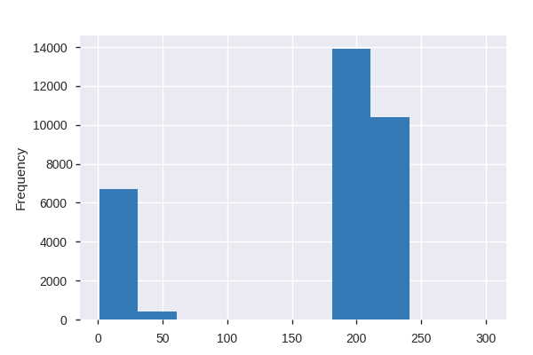

**Common Values**

| Value | Count | Frequency (%) |  |
| --- | --- | --- | --- |
| 202 | 5751 | 18.3% |  |
| 209 | 3085 | 9.8% |  |
| 211 | 2941 | 9.4% |  |
| 214 | 2418 | 7.7% |  |
| 206 | 2009 | 6.4% |  |
| 212 | 1526 | 4.9% |  |
| 14 | 1498 | 4.8% |  |
| 13 | 1366 | 4.3% |  |
| 208 | 1042 | 3.3% |  |
| 213 | 999 | 3.2% |  |
| Other values (58) | 8784 | 28.0% |  |

**Extreme Values**

Minimum 5 values

| Value | Count | Frequency (%) |  |
| --- | --- | --- | --- |
| 1 | 38 | 0.1% |  |
| 2 | 286 | 0.9% |  |
| 3 | 7 | 0.0% |  |
| 4 | 670 | 2.1% |  |
| 5 | 77 | 0.2% |  |

Maximum 5 values

| Value | Count | Frequency (%) |  |
| --- | --- | --- | --- |
| 228 | 168 | 0.5% |  |
| 229 | 128 | 0.4% |  |
| 230 | 69 | 0.2% |  |
| 231 | 9 | 0.0% |  |
| 301 | 4 | 0.0% |  |

SECOND_VIOLATION  
Highly correlated

*This variable is highly correlated with `FIRST_VIOLATION` and should be ignored for analysis*

| Correlation | 0.99692 |
| --- | --- |

THIRD_VIOLATION  
Highly correlated

*This variable is highly correlated with `SECOND_VIOLATION` and should be ignored for analysis*

| Correlation | 0.98679 |
| --- | --- |

FIRST_VIOLATION_DS  
Categorical

| Distinct count | 68 |
| --- | --- |
| Unique (%) | 0.2% |
| Missing (%) | 0.0% |
| Missing (n) | 0 |

| Handwashing (as required, when required, proper glove use, no bare hand contact of ready to eat foods). Foodhandler health restrictions as required. | 5751 |
| --- | --- |
| PHF/TCSs at proper temperatures during storage, display, service, transport, and holding. | 3085 |
| Food protected from potential contamination during storage and preparation. | 2941 |
| Other values (65) | 19642 |

Toggle details

| Value | Count | Frequency (%) |  |
| --- | --- | --- | --- |
| Handwashing (as required, when required, proper glove use, no bare hand contact of ready to eat foods). Foodhandler health restrictions as required. | 5751 | 18.3% |  |
| PHF/TCSs at proper temperatures during storage, display, service, transport, and holding. | 3085 | 9.8% |  |
| Food protected from potential contamination during storage and preparation. | 2941 | 9.4% |  |
| Kitchenware and food contact surfaces of equipment properly washed, rinsed, sanitized and air dried. Sanitizer solution provided and maintained as required. | 2418 | 7.7% |  |
| Food wholesome | 2009 | 6.4% |  |
| Food protected from potential contamination by chemicals. Toxic items properly labeled, stored and used. | 1526 | 4.9% |  |
| Kitchenware and/or food contact surfaces of equipment improperly cleaned, sanitized and/or air dried. | 1498 | 4.8% |  |
| Unsuitable hand washing facilities, unclean, inaccessible and/or not in good repair, with unapproved soap, towels and/or waste receptacles not provided. | 1366 | 4.3% |  |
| PHF/TCSs properly cooled. | 1042 | 3.3% |  |
| Food protected from potential contamination by employees and consumers. | 999 | 3.2% |  |
| Other values (58) | 8784 | 28.0% |  |

SECOND_VIOLATION_DS  
Categorical

| Distinct count | 74 |
| --- | --- |
| Unique (%) | 0.2% |
| Missing (%) | 0.0% |
| Missing (n) | 0 |

| Food protected from potential contamination during storage and preparation. | 3210 |
| --- | --- |
| PHF/TCSs at proper temperatures during storage, display, service, transport, and holding. | 2849 |
| Handwashing facilities adequate in number, stocked, accessible, and limited to handwashing only. | 2372 |
| Other values (71) | 22988 |

Toggle details

| Value | Count | Frequency (%) |  |
| --- | --- | --- | --- |
| Food protected from potential contamination during storage and preparation. | 3210 | 10.2% |  |
| PHF/TCSs at proper temperatures during storage, display, service, transport, and holding. | 2849 | 9.1% |  |
| Handwashing facilities adequate in number, stocked, accessible, and limited to handwashing only. | 2372 | 7.5% |  |
| Kitchenware and food contact surfaces of equipment properly washed, rinsed, sanitized and air dried. Sanitizer solution provided and maintained as required. | 2299 | 7.3% |  |
| Food protected from potential contamination by chemicals. Toxic items properly labeled, stored and used. | 1837 | 5.8% |  |
| Food protected from potential contamination by employees and consumers. | 1647 | 5.2% |  |
| Food wholesome | 1069 | 3.4% |  |
| Kitchenware and/or food contact surfaces of equipment improperly cleaned, sanitized and/or air dried. | 955 | 3.0% |  |
| Nonfood contact surfaces and equipment properly constructed, installed, maintained and clean. | 937 | 3.0% |  |
| Non-food contact surfaces and/or cooking devices not maintained and/or unclean. | 909 | 2.9% |  |
| Other values (64) | 13335 | 42.4% |  |

THIRD_VIOLATION_DS  
Categorical

| Distinct count | 82 |
| --- | --- |
| Unique (%) | 0.3% |
| Missing (%) | 0.0% |
| Missing (n) | 0 |

| Handwashing facilities adequate in number, stocked, accessible, and limited to handwashing only. | 2682 |
| --- | --- |
| Food protected from potential contamination during storage and preparation. | 2262 |
| Facility in sound condition and maintained (floors, walls, ceilings, plumbing, lighting, ventilation, etc.). | 2233 |
| Other values (79) | 24242 |

Toggle details

| Value | Count | Frequency (%) |  |
| --- | --- | --- | --- |
| Handwashing facilities adequate in number, stocked, accessible, and limited to handwashing only. | 2682 | 8.5% |  |
| Food protected from potential contamination during storage and preparation. | 2262 | 7.2% |  |
| Facility in sound condition and maintained (floors, walls, ceilings, plumbing, lighting, ventilation, etc.). | 2233 | 7.1% |  |
| Nonfood contact surfaces and equipment properly constructed, installed, maintained and clean. | 1792 | 5.7% |  |
| Food protected from potential contamination by employees and consumers. | 1592 | 5.1% |  |
| Food protected from potential contamination by chemicals. Toxic items properly labeled, stored and used. | 1458 | 4.6% |  |
| Hot and cold holding equipment present | 1182 | 3.8% |  |
| Utensils, equipment, and single serve items properly handled, stored, and dispensed. | 1179 | 3.8% |  |
| Effective pest control measures. Animals restricted as required. | 1179 | 3.8% |  |
| PHF/TCSs at proper temperatures during storage, display, service, transport, and holding. | 1056 | 3.4% |  |
| Other values (72) | 14804 | 47.1% |  |

FIRST_VIOLATION_TYPE  
Categorical

| Distinct count | 4 |
| --- | --- |
| Unique (%) | 0.0% |
| Missing (%) | 0.0% |
| Missing (n) | 0 |

| Critical | 14675 |
| --- | --- |
| Major | 13446 |
| Non-Major | 3294 |

Toggle details

| Value | Count | Frequency (%) |  |
| --- | --- | --- | --- |
| Critical | 14675 | 46.7% |  |
| Major | 13446 | 42.8% |  |
| Non-Major | 3294 | 10.5% |  |
| Imminent Health Hazard | 4 | 0.0% |  |

SECOND_VIOLATION_TYPE  
Categorical

| Distinct count | 4 |
| --- | --- |
| Unique (%) | 0.0% |
| Missing (%) | 0.0% |
| Missing (n) | 0 |

| Major | 16153 |
| --- | --- |
| Non-Major | 9147 |
| Critical | 6111 |

Toggle details

| Value | Count | Frequency (%) |  |
| --- | --- | --- | --- |
| Major | 16153 | 51.4% |  |
| Non-Major | 9147 | 29.1% |  |
| Critical | 6111 | 19.5% |  |
| Imminent Health Hazard | 8 | 0.0% |  |

THIRD_VIOLATION_TYPE  
Categorical

| Distinct count | 4 |
| --- | --- |
| Unique (%) | 0.0% |
| Missing (%) | 0.0% |
| Missing (n) | 0 |

| Non-Major | 14819 |
| --- | --- |
| Major | 14685 |
| Critical | 1838 |

Toggle details

| Value | Count | Frequency (%) |  |
| --- | --- | --- | --- |
| Non-Major | 14819 | 47.2% |  |
| Major | 14685 | 46.7% |  |
| Critical | 1838 | 5.8% |  |
| Imminent Health Hazard | 77 | 0.2% |  |

NUMBER_OF_VIOLATIONS  
Numeric

| Distinct count | 27 |
| --- | --- |
| Unique (%) | 0.1% |
| Missing (%) | 0.0% |
| Missing (n) | 0 |
| Infinite (%) | 0.0% |
| Infinite (n) | 0 |

| Mean | 5.7374 |
| --- | --- |
| Minimum | 3 |
| Maximum | 30 |
| Zeros (%) | 0.0% |

Toggle details

**Statistics**

Quantile statistics

| Minimum | 3 |
| --- | --- |
| 5-th percentile | 3 |
| Q1 | 4 |
| Median | 5 |
| Q3 | 7 |
| 95-th percentile | 12 |
| Maximum | 30 |
| Range | 27 |
| Interquartile range | 3 |

Descriptive statistics

| Standard deviation | 3.0067 |
| --- | --- |
| Coef of variation | 0.52405 |
| Kurtosis | 4.1726 |
| Mean | 5.7374 |
| MAD | 2.2794 |
| Skewness | 1.7445 |
| Sum | 180264 |
| Variance | 9.0403 |
| Memory size | 245.6 KiB |

**Histogram**

[figure not shown]

**Common Values**

| Value | Count | Frequency (%) |  |
| --- | --- | --- | --- |
| 3 | 7434 | 23.7% |  |
| 4 | 7175 | 22.8% |  |
| 5 | 4058 | 12.9% |  |
| 6 | 3507 | 11.2% |  |
| 7 | 2451 | 7.8% |  |
| 8 | 2001 | 6.4% |  |
| 9 | 1294 | 4.1% |  |
| 10 | 1035 | 3.3% |  |
| 11 | 673 | 2.1% |  |
| 12 | 541 | 1.7% |  |
| Other values (17) | 1250 | 4.0% |  |

**Extreme Values**

Minimum 5 values

| Value | Count | Frequency (%) |  |
| --- | --- | --- | --- |
| 3 | 7434 | 23.7% |  |
| 4 | 7175 | 22.8% |  |
| 5 | 4058 | 12.9% |  |
| 6 | 3507 | 11.2% |  |
| 7 | 2451 | 7.8% |  |

Maximum 5 values

| Value | Count | Frequency (%) |  |
| --- | --- | --- | --- |
| 25 | 5 | 0.0% |  |
| 26 | 1 | 0.0% |  |
| 27 | 1 | 0.0% |  |
| 28 | 1 | 0.0% |  |
| 30 | 5 | 0.0% |  |

Correlations

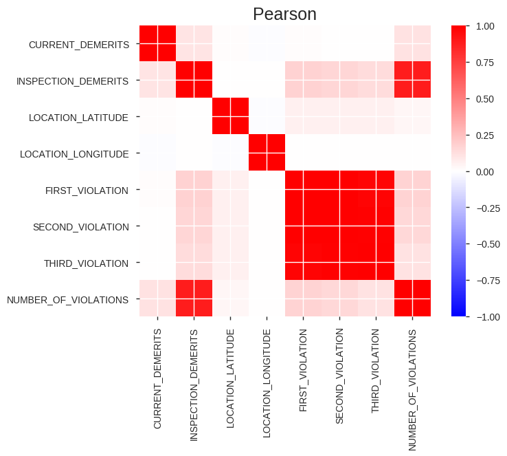

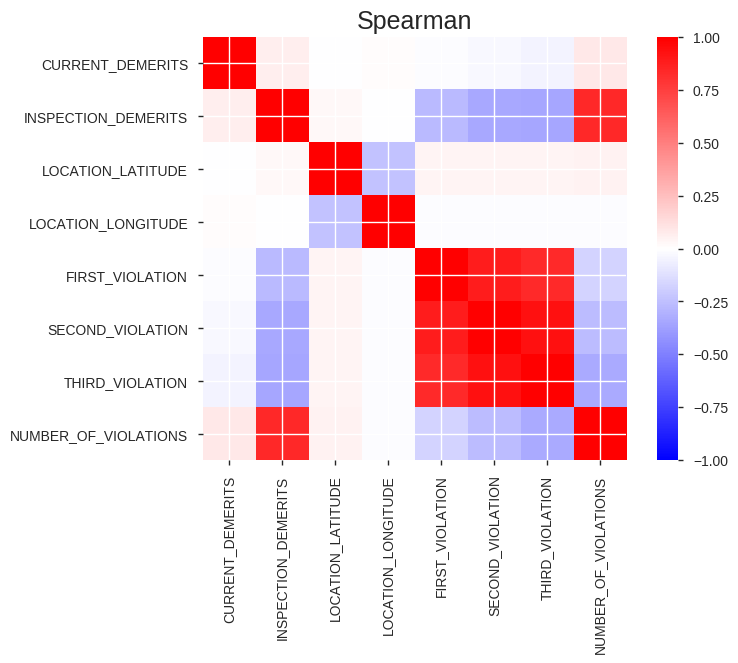

Sample

|  | RESTAURANT_SERIAL_NUMBER | RESTAURANT_PERMIT_NUMBER | RESTAURANT_NAME | RESTAURANT_LOCATION | RESTAURANT_CATEGORY | ADDRESS | CITY | STATE | ZIP | CURRENT_DEMERITS | CURRENT_GRADE | DATE_CURRENT | INSPECTION_DATE | INSPECTION_DATE_RAW | INSPECTION_TIME | EMPLOYEE_ID | INSPECTION_TYPE | INSPECTION_DEMERITS | INSPECTION_GRADE | PERMIT_STATUS | INSPECTION_RESULT | VIOLATIONS_RAW | RECORD_UPDATED | LAT_LONG_RAW | LOCATION_LATITUDE | LOCATION_LONGITUDE | FIRST_VIOLATION | SECOND_VIOLATION | THIRD_VIOLATION | … |
| --- | --- | --- | --- | --- | --- | --- | --- | --- | --- | --- | --- | --- | --- | --- | --- | --- | --- | --- | --- | --- | --- | --- | --- | --- | --- | --- | --- | --- | --- | --- |
| 0 | DA0224668 | PR0005123 | Rio Seafood Buffet - Seafood Grill - DELETED 6/29/16 AS | Rio Suites Hotel | Banquet Support | 3700 W Flamingo Rd | Las Vegas | Nevada | 89103-4043 | 5 | A | 06/02/2015 12:00:00 AM | 2010-04-20 | 04/20/2010 12:00:00 AM | 04/20/2010 06:25:00 PM | EE7000806 | Routine Inspection | 10 | A | NaN | Compliant | 1,13,28 | 02/21/2013 10:26:12 PM | (36.1164467, 115.1848942) | 36.116447 | -115.184894 | 1 | 13 | 28 | … |
| 1 | DA0228150 | PR0005172 | Rio Voodoo Restaurant 50th Floor | Rio Suites Hotel | Restaurant | 3700 W Flamingo Rd | Las Vegas | Nevada | 89103-4043 | 8 | A | 06/29/2016 12:00:00 AM | 2010-04-20 | 04/20/2010 12:00:00 AM | 04/20/2010 06:25:00 PM | EE7000806 | Routine Inspection | 10 | A | NaN | Compliant | 1,13,28 | 02/21/2013 10:26:12 PM | (36.1164467, 115.1848942) | 36.116447 | -115.184894 | 1 | 13 | 28 | … |
| 2 | DA0349036 | PR0008199 | CAESARS BALLROOM BEVERAGE BULK STORAGE | CAESARS PALACE HOTEL & CASINO | Pantry | 3570 S Las Vegas Blvd | Las Vegas | Nevada | 89109-8924 | 3 | A | 09/29/2016 12:00:00 AM | 2010-05-21 | 05/21/2010 12:00:00 AM | 05/21/2010 11:20:00 AM | EE7000417 | Routine Inspection | 25 | C | NaN | C Downgrade | 1,4,13,14,21,22,27,28,31,36,37,38 | 02/21/2013 10:26:12 PM | (36.1161559, 115.1750576) | 36.116156 | -115.175058 | 1 | 4 | 13 | … |
| 3 | DA0356449 | PR0007769 | Sumo Japanese Restaurant | Sumo Japanese Restaurant | Restaurant | 2861 N Green Valley Pkwy | Henderson | Nevada | 89014-0403 | 9 | A | 06/06/2016 12:00:00 AM | 2010-01-22 | 01/22/2010 12:00:00 AM | 01/22/2010 03:30:00 PM | EE7000321 | Routine Inspection | 27 | C | NaN | C Downgrade | 1,7,14,19,20,22,31,35,64,112 | 02/21/2013 10:26:12 PM | (36.0729093, 115.0824452) | 36.072909 | -115.082445 | 1 | 7 | 14 | … |
| 4 | DA0417263 | PR0010030 | Doc Hollidays Restaurant | Doc Holidays | Restaurant | 9310 S Eastern Ave #124 | Las Vegas | Nevada | 89123-6843 | 10 | A | 05/18/2012 12:00:00 AM | 2010-02-25 | 02/25/2010 12:00:00 AM | 02/25/2010 01:45:00 PM | EE7000735 | Routine Inspection | 8 | A | NaN | Compliant | 1,28,31 | 02/21/2013 10:26:12 PM | (36.0195687, 115.117206) | 36.019569 | -115.117206 | 1 | 28 | 31 | … |

```python
#Generate Initial report on the dataset using pandas profile reporting
profile = ProfileReport(data)
a=profile.to_html()
display(HTML(a))
```

### **3) Data Cleaning**

**Function Name** : clean_explore

**Parameter** : r_data : original pandas dataframe

**Function Description** :

- Since our objective is to estimate the likelihood of the restaurant receiving First Violation Type as 'Critical', I have encoded this value as '1' and other Violation Types as '0'.So that for every row , we can predict the probabilty of Violation Type as Critical based on the attributes of the restaurant.
- This function also replaces NaN values in one the 'INSPECTION_TIME' time columns with default value '01/01/1900 12:00:00 AM' which is important for our analysis further.
- For the other NaN values in categorical columns ,I replace them with 'Unkown' creating a new category for each of the columns. The purpose of doing this is to preserve information from the restaurnts that have few missing values in them.

```python
def clean_explore(r_data):
  r_data.loc[r_data.FIRST_VIOLATION_TYPE=='Critical','FIRST_VIOLATION_TYPE']=1
  r_data.loc[r_data.FIRST_VIOLATION_TYPE!=1,'FIRST_VIOLATION_TYPE']=0
  r_data['INSPECTION_TIME'].replace(np.nan,'01/01/1900 12:00:00 AM',inplace=True)
  r_data.replace(np.nan,'Unknown',inplace=True)
  return r_data
```

```python
#Perform initial data cleaning and transformation
cleaned_data=clean_explore(data)
```

After looking at the data exploration report it can be infered that there are few columns that are not needed in the analysis which I am dropping from further consideration .

- The columns 'SECOND_VIOLATION_TYPE','THIRD_VIOLATION_TYPE','SECOND_VIOLATION','THIRD_VIOLATION' and their descriptions are not needed in our analysis since we are interested in only predicting the likelihood of 'FIRST_VIOLATION_TYPE' as Critical.Hence,I have dropped these columns.
- The columns 'LOCATION_LONGITUDE','LOCATION_LATITUDE','LAT_LONG_RAW' provide a very granular detail on the location of the restaurant which is not needed in our model building
- Similary the columns 'RECORD_UPDATED','EMPLOYEE_ID','RESTAURANT_PERMIT_NUMBER','STATE'(same value on all rows) add no value to our analysis hence I have dropped them

```python
data=cleaned_data
columnsToBeDroped=['SECOND_VIOLATION_TYPE','THIRD_VIOLATION_TYPE','SECOND_VIOLATION',
                   'THIRD_VIOLATION','LOCATION_LONGITUDE','LOCATION_LATITUDE',
                   'LAT_LONG_RAW','RECORD_UPDATED','EMPLOYEE_ID',
                   'RESTAURANT_PERMIT_NUMBER','STATE','FIRST_VIOLATION_DS','SECOND_VIOLATION_DS',
                   'THIRD_VIOLATION_DS','DATE_CURRENT','INSPECTION_DATE_RAW','VIOLATIONS_RAW','RESTAURANT_NAME','ADDRESS']

if set(columnsToBeDroped).issubset(data.columns):
  data=data.drop(columns=columnsToBeDroped)
print(data.head())
```

```
  RESTAURANT_SERIAL_NUMBER  ... NUMBER_OF_VIOLATIONS
0                DA0224668  ...                    3
1                DA0228150  ...                    3
2                DA0349036  ...                   12
3                DA0356449  ...                   10
4                DA0417263  ...                    3

[5 rows x 17 columns]
```

This is my hypothesis that Inspection Date and Time in itself might not be correlated with Insepction results but the Quarter in which the inspection happens and the hour of the day might be important in determining the inspection results.

Example during rush hours at night some restaurants mightget carless in maintaining adequate hygine conditions and hence may result in critical violation.

Hence ,I have created Inspection Quarter and Inspection Time column in order to preserve information at a little higher level for each restaurants.

```python
for i in range(data.shape[0]):
    a= data.loc[i,'INSPECTION_DATE'].month//3
    quarter = "Q"+str(a)
    data.loc[i,'INSPECTION_QUARTER']=quarter
    if 'PM' in data.loc[i,'INSPECTION_TIME']:
      hour=int(data.loc[i,'INSPECTION_TIME'].split(' ')[1].split(':')[0])+12
      data.loc[i,'INSPECTION_TIME_HOUR']=str(hour)
    else:
      data.loc[i,'INSPECTION_TIME_HOUR']=str(data.loc[i,'INSPECTION_TIME']).split(' ')[1].split(':')[0]
data=data.drop(columns=['INSPECTION_DATE','INSPECTION_TIME'])
```

**Exploratory Report After Data Cleaning**

Overview

Dataset info

| Number of variables | 17 |
| --- | --- |
| Number of observations | 31419 |
| Total Missing (%) | 0.0% |
| Total size in memory | 4.1 MiB |
| Average record size in memory | 136.0 B |

Variables types

| Numeric | 4 |
| --- | --- |
| Categorical | 11 |
| Boolean | 1 |
| Date | 0 |
| Text (Unique) | 1 |
| Rejected | 0 |
| Unsupported | 0 |

Warnings

- `RESTAURANT_LOCATION` has a high cardinality: 6254 distinct values Warning

- `ZIP` has a high cardinality: 2897 distinct values Warning

- `CURRENT_DEMERITS` has 8128 / 25.9% zeros Zeros

Variables

RESTAURANT_SERIAL_NUMBER  
Categorical, Unique

| First 3 values |
| --- |
| DA1025348 |
| DA1669857 |
| DA1137312 |

| Last 3 values |
| --- |
| DA1463794 |
| DA1463177 |
| DA1037811 |

Toggle details

First 10 values

| Value | Count | Frequency (%) |  |
| --- | --- | --- | --- |
| DA0001131 | 1 | 0.0% |  |
| DA0001173 | 1 | 0.0% |  |
| DA0001760 | 1 | 0.0% |  |
| DA0001773 | 1 | 0.0% |  |
| DA0001822 | 1 | 0.0% |  |

Last 10 values

| Value | Count | Frequency (%) |  |
| --- | --- | --- | --- |
| DAZZEIZJM | 1 | 0.0% |  |
| DAZZSE0YW | 1 | 0.0% |  |
| DAZZVFR5I | 1 | 0.0% |  |
| DAZZXYCCX | 1 | 0.0% |  |
| DAZZYV0DF | 1 | 0.0% |  |

RESTAURANT_LOCATION  
Categorical

| Distinct count | 6254 |
| --- | --- |
| Unique (%) | 19.9% |
| Missing (%) | 0.0% |
| Missing (n) | 0 |

| MIRAGE HOTEL & CASINO | 237 |
| --- | --- |
| CAESARS PALACE HOTEL & CASINO | 226 |
| ARIA HOTEL & CASINO | 203 |
| Other values (6251) | 30753 |

Toggle details

| Value | Count | Frequency (%) |  |
| --- | --- | --- | --- |
| MIRAGE HOTEL & CASINO | 237 | 0.8% |  |
| CAESARS PALACE HOTEL & CASINO | 226 | 0.7% |  |
| ARIA HOTEL & CASINO | 203 | 0.6% |  |
| MGM GRAND HOTEL & CASINO | 199 | 0.6% |  |
| PARIS HOTEL & CASINO | 191 | 0.6% |  |
| Robertos Taco Shop | 180 | 0.6% |  |
| MANDALAY BAY HOTEL & CASINO | 176 | 0.6% |  |
| BELLAGIO HOTEL & CASINO | 174 | 0.6% |  |
| HARRAHS LV HOTEL & CASINO | 165 | 0.5% |  |
| COSMOPOLITAN RESORT & CASINO | 164 | 0.5% |  |
| Other values (6244) | 29504 | 93.9% |  |

RESTAURANT_CATEGORY  
Categorical

| Distinct count | 29 |
| --- | --- |
| Unique (%) | 0.1% |
| Missing (%) | 0.0% |
| Missing (n) | 0 |

| Restaurant | 18941 |
| --- | --- |
| Bar / Tavern | 4704 |
| Snack Bar | 2608 |
| Other values (26) | 5166 |

Toggle details

| Value | Count | Frequency (%) |  |
| --- | --- | --- | --- |
| Restaurant | 18941 | 60.3% |  |
| Bar / Tavern | 4704 | 15.0% |  |
| Snack Bar | 2608 | 8.3% |  |
| Special Kitchen | 2313 | 7.4% |  |
| Buffet | 447 | 1.4% |  |
| Portable Unit | 389 | 1.2% |  |
| Pantry | 339 | 1.1% |  |
| Meat/Poultry/Seafood | 302 | 1.0% |  |
| Food Trucks / Mobile Vendor | 202 | 0.6% |  |
| Kitchen Bakery | 145 | 0.5% |  |
| Other values (19) | 1029 | 3.3% |  |

CITY  
Categorical

| Distinct count | 21 |
| --- | --- |
| Unique (%) | 0.1% |
| Missing (%) | 0.0% |
| Missing (n) | 0 |

| Las Vegas | 25186 |
| --- | --- |
| Henderson | 3011 |
| North Las Vegas | 1897 |
| Other values (18) | 1325 |

Toggle details

| Value | Count | Frequency (%) |  |
| --- | --- | --- | --- |
| Las Vegas | 25186 | 80.2% |  |
| Henderson | 3011 | 9.6% |  |
| North Las Vegas | 1897 | 6.0% |  |
| Laughlin | 396 | 1.3% |  |
| Mesquite | 320 | 1.0% |  |
| Boulder City | 272 | 0.9% |  |
| Primm | 197 | 0.6% |  |
| Searchlight | 24 | 0.1% |  |
| Overton | 21 | 0.1% |  |
| Indian Springs | 20 | 0.1% |  |
| Other values (11) | 75 | 0.2% |  |

ZIP  
Categorical

| Distinct count | 2897 |
| --- | --- |
| Unique (%) | 9.2% |
| Missing (%) | 0.0% |
| Missing (n) | 0 |

| 89109 | 929 |
| --- | --- |
| 89102 | 400 |
| 89119 | 358 |
| Other values (2894) | 29732 |

Toggle details

| Value | Count | Frequency (%) |  |
| --- | --- | --- | --- |
| 89109 | 929 | 3.0% |  |
| 89102 | 400 | 1.3% |  |
| 89119 | 358 | 1.1% |  |
| 89101 | 328 | 1.0% |  |
| 89109-8941 | 320 | 1.0% |  |
| 89146 | 312 | 1.0% |  |
| 89130 | 300 | 1.0% |  |
| 89103 | 275 | 0.9% |  |
| 89109-8923 | 274 | 0.9% |  |
| 89109-4319 | 263 | 0.8% |  |
| Other values (2887) | 27660 | 88.0% |  |

CURRENT_DEMERITS  
Numeric

| Distinct count | 49 |
| --- | --- |
| Unique (%) | 0.2% |
| Missing (%) | 0.0% |
| Missing (n) | 0 |
| Infinite (%) | 0.0% |
| Infinite (n) | 0 |

| Mean | 5.0367 |
| --- | --- |
| Minimum | 0 |
| Maximum | 100 |
| Zeros (%) | 25.9% |

Toggle details

**Statistics**

Quantile statistics

| Minimum | 0 |
| --- | --- |
| 5-th percentile | 0 |
| Q1 | 0 |
| Median | 5 |
| Q3 | 8 |
| 95-th percentile | 10 |
| Maximum | 100 |
| Range | 100 |
| Interquartile range | 8 |

Descriptive statistics

| Standard deviation | 5.0503 |
| --- | --- |
| Coef of variation | 1.0027 |
| Kurtosis | 67.905 |
| Mean | 5.0367 |
| MAD | 3.4631 |
| Skewness | 5.0027 |
| Sum | 158247 |
| Variance | 25.505 |
| Memory size | 245.6 KiB |

**Histogram**

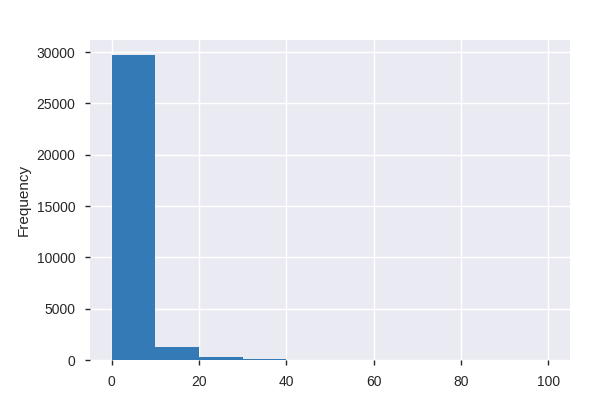

**Common Values**

| Value | Count | Frequency (%) |  |
| --- | --- | --- | --- |
| 0 | 8128 | 25.9% |  |
| 3 | 6213 | 19.8% |  |
| 8 | 5062 | 16.1% |  |
| 6 | 4393 | 14.0% |  |
| 9 | 3828 | 12.2% |  |
| 5 | 1557 | 5.0% |  |
| 10 | 926 | 2.9% |  |
| 7 | 213 | 0.7% |  |
| 4 | 130 | 0.4% |  |
| 19 | 120 | 0.4% |  |
| Other values (39) | 849 | 2.7% |  |

**Extreme Values**

Minimum 5 values

| Value | Count | Frequency (%) |  |
| --- | --- | --- | --- |
| 0 | 8128 | 25.9% |  |
| 1 | 95 | 0.3% |  |
| 2 | 78 | 0.2% |  |
| 3 | 6213 | 19.8% |  |
| 4 | 130 | 0.4% |  |

Maximum 5 values

| Value | Count | Frequency (%) |  |
| --- | --- | --- | --- |
| 51 | 8 | 0.0% |  |
| 61 | 3 | 0.0% |  |
| 88 | 2 | 0.0% |  |
| 89 | 2 | 0.0% |  |
| 100 | 12 | 0.0% |  |

CURRENT_GRADE  
Categorical

| Distinct count | 7 |
| --- | --- |
| Unique (%) | 0.0% |
| Missing (%) | 0.0% |
| Missing (n) | 0 |

| A | 30523 |
| --- | --- |
| B | 437 |
| C | 210 |
| Other values (4) | 249 |

Toggle details

| Value | Count | Frequency (%) |  |
| --- | --- | --- | --- |
| A | 30523 | 97.1% |  |
| B | 437 | 1.4% |  |
| C | 210 | 0.7% |  |
| X | 136 | 0.4% |  |
| O | 76 | 0.2% |  |
| N | 28 | 0.1% |  |
| Unknown | 9 | 0.0% |  |

INSPECTION_TYPE  
Categorical

| Distinct count | 3 |
| --- | --- |
| Unique (%) | 0.0% |
| Missing (%) | 0.0% |
| Missing (n) | 0 |

| Routine Inspection | 29652 |
| --- | --- |
| Re-inspection | 1766 |
| Epidemiological Investigation | 1 |

Toggle details

| Value | Count | Frequency (%) |  |
| --- | --- | --- | --- |
| Routine Inspection | 29652 | 94.4% |  |
| Re-inspection | 1766 | 5.6% |  |
| Epidemiological Investigation | 1 | 0.0% |  |

INSPECTION_DEMERITS  
Numeric

| Distinct count | 69 |
| --- | --- |
| Unique (%) | 0.2% |
| Missing (%) | 0.0% |
| Missing (n) | 0 |
| Infinite (%) | 0.0% |
| Infinite (n) | 0 |

| Mean | 13.591 |
| --- | --- |
| Minimum | 0 |
| Maximum | 89 |
| Zeros (%) | 0.0% |

Toggle details

**Statistics**

Quantile statistics

| Minimum | 0 |
| --- | --- |
| 5-th percentile | 4 |
| Q1 | 8 |
| Median | 10 |
| Q3 | 19 |
| 95-th percentile | 31 |
| Maximum | 89 |
| Range | 89 |
| Interquartile range | 11 |

Descriptive statistics

| Standard deviation | 8.478 |
| --- | --- |
| Coef of variation | 0.62382 |
| Kurtosis | 3.2875 |
| Mean | 13.591 |
| MAD | 6.6795 |
| Skewness | 1.5015 |
| Sum | 427002 |
| Variance | 71.877 |
| Memory size | 245.6 KiB |

**Histogram**

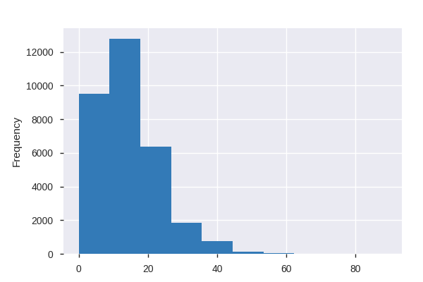

**Common Values**

| Value | Count | Frequency (%) |  |
| --- | --- | --- | --- |
| 10 | 3962 | 12.6% |  |
| 9 | 3738 | 11.9% |  |
| 19 | 2344 | 7.5% |  |
| 20 | 2275 | 7.2% |  |
| 7 | 2251 | 7.2% |  |
| 8 | 2129 | 6.8% |  |
| 5 | 1853 | 5.9% |  |
| 6 | 1612 | 5.1% |  |
| 17 | 1594 | 5.1% |  |
| 3 | 1246 | 4.0% |  |
| Other values (59) | 8415 | 26.8% |  |

**Extreme Values**

Minimum 5 values

| Value | Count | Frequency (%) |  |
| --- | --- | --- | --- |
| 0 | 14 | 0.0% |  |
| 3 | 1246 | 4.0% |  |
| 4 | 416 | 1.3% |  |
| 5 | 1853 | 5.9% |  |
| 6 | 1612 | 5.1% |  |

Maximum 5 values

| Value | Count | Frequency (%) |  |
| --- | --- | --- | --- |
| 70 | 2 | 0.0% |  |
| 77 | 1 | 0.0% |  |
| 82 | 1 | 0.0% |  |
| 86 | 2 | 0.0% |  |
| 89 | 1 | 0.0% |  |

INSPECTION_GRADE  
Categorical

| Distinct count | 9 |
| --- | --- |
| Unique (%) | 0.0% |
| Missing (%) | 0.0% |
| Missing (n) | 0 |

| A | 16645 |
| --- | --- |
| B | 10147 |
| C | 3340 |
| Other values (6) | 1287 |

Toggle details

| Value | Count | Frequency (%) |  |
| --- | --- | --- | --- |
| A | 16645 | 53.0% |  |
| B | 10147 | 32.3% |  |
| C | 3340 | 10.6% |  |
| X | 846 | 2.7% |  |
| P | 279 | 0.9% |  |
| Unknown | 78 | 0.2% |  |
| O | 68 | 0.2% |  |
| a | 15 | 0.0% |  |
| N | 1 | 0.0% |  |

PERMIT_STATUS  
Categorical

| Distinct count | 7 |
| --- | --- |
| Unique (%) | 0.0% |
| Missing (%) | 0.0% |
| Missing (n) | 0 |

| Unknown | 24500 |
| --- | --- |
| A | 3258 |
| B | 2396 |
| Other values (4) | 1265 |

Toggle details

| Value | Count | Frequency (%) |  |
| --- | --- | --- | --- |
| Unknown | 24500 | 78.0% |  |
| A | 3258 | 10.4% |  |
| B | 2396 | 7.6% |  |
| C | 780 | 2.5% |  |
| PASS | 275 | 0.9% |  |
| CLOSED | 194 | 0.6% |  |
| APPROVED | 16 | 0.1% |  |

INSPECTION_RESULT  
Categorical

| Distinct count | 18 |
| --- | --- |
| Unique (%) | 0.1% |
| Missing (%) | 0.0% |
| Missing (n) | 0 |

| Compliant | 16853 |
| --- | --- |
| B Downgrade | 10025 |
| C Downgrade | 3322 |
| Other values (15) | 1219 |

Toggle details

| Value | Count | Frequency (%) |  |
| --- | --- | --- | --- |
| Compliant | 16853 | 53.6% |  |
| B Downgrade | 10025 | 31.9% |  |
| C Downgrade | 3322 | 10.6% |  |
| Closed with Fees | 810 | 2.6% |  |
| A Grade | 291 | 0.9% |  |
| Approved | 68 | 0.2% |  |
| Closed without Fees | 27 | 0.1% |  |
| Follow Up Required | 5 | 0.0% |  |
| Compliance Schedule | 3 | 0.0% |  |
| Complaint Invalid/Unsubstantiated | 3 | 0.0% |  |
| Other values (8) | 12 | 0.0% |  |

FIRST_VIOLATION  
Numeric

| Distinct count | 68 |
| --- | --- |
| Unique (%) | 0.2% |
| Missing (%) | 0.0% |
| Missing (n) | 0 |
| Infinite (%) | 0.0% |
| Infinite (n) | 0 |

| Mean | 164.92 |
| --- | --- |
| Minimum | 1 |
| Maximum | 301 |
| Zeros (%) | 0.0% |

Toggle details

**Statistics**

Quantile statistics

| Minimum | 1 |
| --- | --- |
| 5-th percentile | 10 |
| Q1 | 202 |
| Median | 206 |
| Q3 | 211 |
| 95-th percentile | 216 |
| Maximum | 301 |
| Range | 300 |
| Interquartile range | 9 |

Descriptive statistics

| Standard deviation | 81.455 |
| --- | --- |
| Coef of variation | 0.4939 |
| Kurtosis | -0.28346 |
| Mean | 164.92 |
| MAD | 68.018 |
| Skewness | -1.2955 |
| Sum | 5181656 |
| Variance | 6634.9 |
| Memory size | 245.6 KiB |

**Histogram**

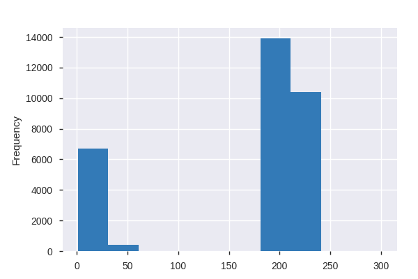

**Common Values**

| Value | Count | Frequency (%) |  |
| --- | --- | --- | --- |
| 202 | 5751 | 18.3% |  |
| 209 | 3085 | 9.8% |  |
| 211 | 2941 | 9.4% |  |
| 214 | 2418 | 7.7% |  |
| 206 | 2009 | 6.4% |  |
| 212 | 1526 | 4.9% |  |
| 14 | 1498 | 4.8% |  |
| 13 | 1366 | 4.3% |  |
| 208 | 1042 | 3.3% |  |
| 213 | 999 | 3.2% |  |
| Other values (58) | 8784 | 28.0% |  |

**Extreme Values**

Minimum 5 values

| Value | Count | Frequency (%) |  |
| --- | --- | --- | --- |
| 1 | 38 | 0.1% |  |
| 2 | 286 | 0.9% |  |
| 3 | 7 | 0.0% |  |
| 4 | 670 | 2.1% |  |
| 5 | 77 | 0.2% |  |

Maximum 5 values

| Value | Count | Frequency (%) |  |
| --- | --- | --- | --- |
| 228 | 168 | 0.5% |  |
| 229 | 128 | 0.4% |  |
| 230 | 69 | 0.2% |  |
| 231 | 9 | 0.0% |  |
| 301 | 4 | 0.0% |  |

FIRST_VIOLATION_TYPE  
Boolean

| Distinct count | 2 |
| --- | --- |
| Unique (%) | 0.0% |
| Missing (%) | 0.0% |
| Missing (n) | 0 |

| Mean | 0.46707 |
| --- | --- |

| 0 | 16744 |
| --- | --- |
| 1 | 14675 |

Toggle details

| Value | Count | Frequency (%) |  |
| --- | --- | --- | --- |
| 0 | 16744 | 53.3% |  |
| 1 | 14675 | 46.7% |  |

NUMBER_OF_VIOLATIONS  
Numeric

| Distinct count | 27 |
| --- | --- |
| Unique (%) | 0.1% |
| Missing (%) | 0.0% |
| Missing (n) | 0 |
| Infinite (%) | 0.0% |
| Infinite (n) | 0 |

| Mean | 5.7374 |
| --- | --- |
| Minimum | 3 |
| Maximum | 30 |
| Zeros (%) | 0.0% |

Toggle details

**Statistics**

Quantile statistics

| Minimum | 3 |
| --- | --- |
| 5-th percentile | 3 |
| Q1 | 4 |
| Median | 5 |
| Q3 | 7 |
| 95-th percentile | 12 |
| Maximum | 30 |
| Range | 27 |
| Interquartile range | 3 |

Descriptive statistics

| Standard deviation | 3.0067 |
| --- | --- |
| Coef of variation | 0.52405 |
| Kurtosis | 4.1726 |
| Mean | 5.7374 |
| MAD | 2.2794 |
| Skewness | 1.7445 |
| Sum | 180264 |
| Variance | 9.0403 |
| Memory size | 245.6 KiB |

**Histogram**

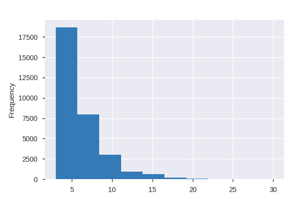

**Common Values**

| Value | Count | Frequency (%) |  |
| --- | --- | --- | --- |
| 3 | 7434 | 23.7% |  |
| 4 | 7175 | 22.8% |  |
| 5 | 4058 | 12.9% |  |
| 6 | 3507 | 11.2% |  |
| 7 | 2451 | 7.8% |  |
| 8 | 2001 | 6.4% |  |
| 9 | 1294 | 4.1% |  |
| 10 | 1035 | 3.3% |  |
| 11 | 673 | 2.1% |  |
| 12 | 541 | 1.7% |  |
| Other values (17) | 1250 | 4.0% |  |

**Extreme Values**

Minimum 5 values

| Value | Count | Frequency (%) |  |
| --- | --- | --- | --- |
| 3 | 7434 | 23.7% |  |
| 4 | 7175 | 22.8% |  |
| 5 | 4058 | 12.9% |  |
| 6 | 3507 | 11.2% |  |
| 7 | 2451 | 7.8% |  |

Maximum 5 values

| Value | Count | Frequency (%) |  |
| --- | --- | --- | --- |
| 25 | 5 | 0.0% |  |
| 26 | 1 | 0.0% |  |
| 27 | 1 | 0.0% |  |
| 28 | 1 | 0.0% |  |
| 30 | 5 | 0.0% |  |

INSPECTION_QUARTER  
Categorical

| Distinct count | 5 |
| --- | --- |
| Unique (%) | 0.0% |
| Missing (%) | 0.0% |
| Missing (n) | 0 |

| Q2 | 9129 |
| --- | --- |
| Q1 | 8175 |
| Q3 | 7714 |
| Other values (2) | 6401 |

Toggle details

| Value | Count | Frequency (%) |  |
| --- | --- | --- | --- |
| Q2 | 9129 | 29.1% |  |
| Q1 | 8175 | 26.0% |  |
| Q3 | 7714 | 24.6% |  |
| Q0 | 5077 | 16.2% |  |
| Q4 | 1324 | 4.2% |  |

INSPECTION_TIME_HOUR  
Categorical

| Distinct count | 24 |
| --- | --- |
| Unique (%) | 0.1% |
| Missing (%) | 0.0% |
| Missing (n) | 0 |

| 14 | 4882 |
| --- | --- |
| 13 | 4577 |
| 15 | 4341 |
| Other values (21) | 17619 |

Toggle details

| Value | Count | Frequency (%) |  |
| --- | --- | --- | --- |
| 14 | 4882 | 15.5% |  |
| 13 | 4577 | 14.6% |  |
| 15 | 4341 | 13.8% |  |
| 11 | 3747 | 11.9% |  |
| 24 | 3648 | 11.6% |  |
| 10 | 2751 | 8.8% |  |
| 08 | 1867 | 5.9% |  |
| 09 | 1658 | 5.3% |  |
| 16 | 1255 | 4.0% |  |
| 17 | 794 | 2.5% |  |
| Other values (14) | 1899 | 6.0% |  |

Correlations

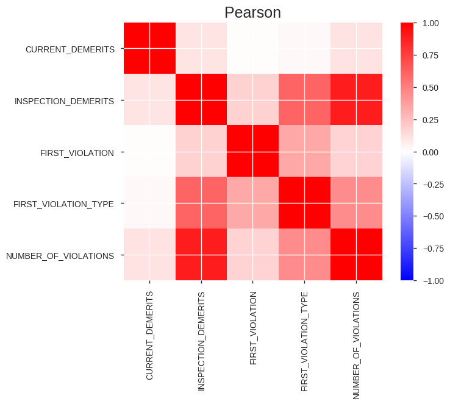

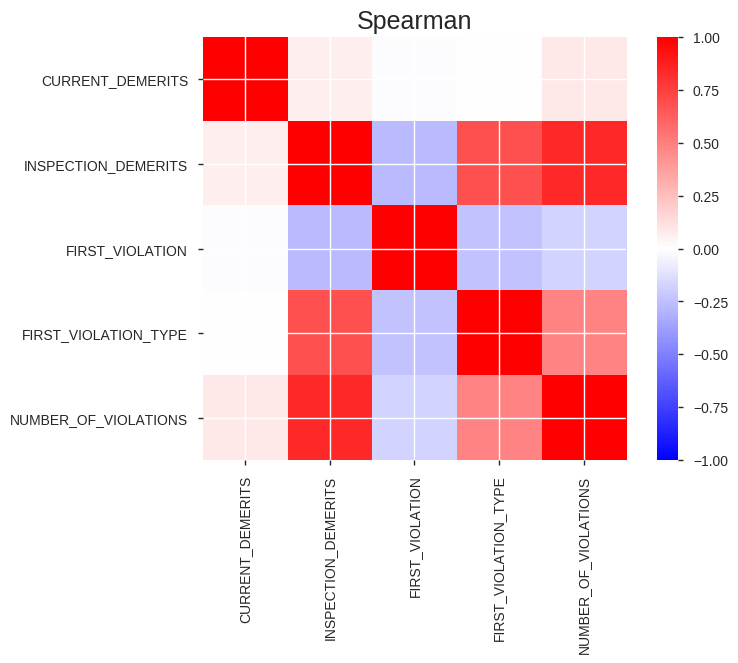

Sample

|  | RESTAURANT_SERIAL_NUMBER | RESTAURANT_LOCATION | RESTAURANT_CATEGORY | CITY | ZIP | CURRENT_DEMERITS | CURRENT_GRADE | INSPECTION_TYPE | INSPECTION_DEMERITS | INSPECTION_GRADE | PERMIT_STATUS | INSPECTION_RESULT | FIRST_VIOLATION | FIRST_VIOLATION_TYPE | NUMBER_OF_VIOLATIONS | INSPECTION_QUARTER | INSPECTION_TIME_HOUR |
| --- | --- | --- | --- | --- | --- | --- | --- | --- | --- | --- | --- | --- | --- | --- | --- | --- | --- |
| 0 | DA0224668 | Rio Suites Hotel | Banquet Support | Las Vegas | 89103-4043 | 5 | A | Routine Inspection | 10 | A | Unknown | Compliant | 1 | 1 | 3 | Q1 | 18 |
| 1 | DA0228150 | Rio Suites Hotel | Restaurant | Las Vegas | 89103-4043 | 8 | A | Routine Inspection | 10 | A | Unknown | Compliant | 1 | 1 | 3 | Q1 | 18 |
| 2 | DA0349036 | CAESARS PALACE HOTEL & CASINO | Pantry | Las Vegas | 89109-8924 | 3 | A | Routine Inspection | 25 | C | Unknown | C Downgrade | 1 | 1 | 12 | Q1 | 11 |
| 3 | DA0356449 | Sumo Japanese Restaurant | Restaurant | Henderson | 89014-0403 | 9 | A | Routine Inspection | 27 | C | Unknown | C Downgrade | 1 | 1 | 10 | Q0 | 15 |
| 4 | DA0417263 | Doc Holidays | Restaurant | Las Vegas | 89123-6843 | 10 | A | Routine Inspection | 8 | A | Unknown | Compliant | 1 | 1 | 3 | Q0 | 13 |

```python
profile_cleaned = ProfileReport(data)
cleaned_report=profile_cleaned.to_html()
display(HTML(cleaned_report))
```

**Function Name**: train_test

**Function Paramter** : Cleaned Data

**Function Description** : Takes the cleaned data and separates the Feature variables from the target variable which is ' FIRST_VIOLATION_TYPE' in our case and then split the Data in Train Test split in 80:20 proportion. This function retunrs the Train split and Test split of the feature and the target variables.

```python
def train_test(data):
  data_label=data['FIRST_VIOLATION_TYPE']
  data_features=data.loc[:, data.columns != 'FIRST_VIOLATION_TYPE']
  X_train, X_test, y_train, y_test = train_test_split(data_features, data_label, test_size=0.2)
  print(X_train.shape, y_train.shape)
  print(X_test.shape, y_test.shape)
  return X_train, X_test, y_train, y_test
```

```python
#Call the train test split
X_train, X_test, y_train, y_test = train_test(data)
print(X_train.shape, y_train.shape)
print(X_test.shape, y_test.shape)
```

```
(25135, 16) (25135,)
(6284, 16) (6284,)
(25135, 16) (25135,)
(6284, 16) (6284,)
```

### **4) Data Transformation**

Many features in our dataset are categorical variables which needs to be encoded into numerical representation inorder to be used for our modeling algorithm. The most commonly used approaches for this is One Hot Encoding and Dummy encoding which created n and n-1 columns respectively ,where n is the number of distinct values in that column.Since our dataset contain many categorical value and they are with many number of distinct values ,I would not go ahead with one hot encoding or dummy encoding since it is going to explode my dataset size.

Hence, I plan to use **Target Encoding** which encodes the categorical variable based on the target values in just one column.

**One important thing to keep in mind is that Target Encoding needs to be done on Train and Test set separately otherwise it creates the risk of Data Leakage.**

**Function Name**: Data Transformation

**Parameter**: One pandas Dataframe with Features and other with Labels

**Function Description**: This function encodes the categorical variables using Taregt Encoding method and encodes the numerical variables using MinMax Scalaer approach scaling the entire dataset in the range of 0 and 1.

```python
def data_transformation(X,Y):
  te_data=ce.TargetEncoder(cols=['RESTAURANT_LOCATION','RESTAURANT_CATEGORY','CITY','ZIP','CURRENT_GRADE','INSPECTION_TYPE',
                                'INSPECTION_GRADE', 'PERMIT_STATUS', 'INSPECTION_RESULT',
                                'FIRST_VIOLATION','INSPECTION_QUARTER',
                                'INSPECTION_TIME_HOUR'])
  te = te_data.fit_transform(X,Y)
  te['CURRENT_DEMERITS']=(te['CURRENT_DEMERITS']-te['CURRENT_DEMERITS'].min())/te['CURRENT_DEMERITS'].max()
  te['INSPECTION_DEMERITS']=(te['INSPECTION_DEMERITS']-te['INSPECTION_DEMERITS'].min())/te['INSPECTION_DEMERITS'].max()
  te['NUMBER_OF_VIOLATIONS']=(te['NUMBER_OF_VIOLATIONS']-te['NUMBER_OF_VIOLATIONS'].min())/te['NUMBER_OF_VIOLATIONS'].max()
  te.index=X['RESTAURANT_SERIAL_NUMBER']

  return te
```

```python
#Perform Data Transformation on Tarining and Test Data
te_train= data_transformation(X_train,y_train)
test_feature = data_transformation(X_test,y_test)
```

```python
y_test.index = test_feature['RESTAURANT_SERIAL_NUMBER']
y_train.index=te_train['RESTAURANT_SERIAL_NUMBER']
```

```python
te_train=te_train.drop(columns='RESTAURANT_SERIAL_NUMBER')
test_feature=test_feature.drop(columns='RESTAURANT_SERIAL_NUMBER')
```

### **5) Model Building**

**Function Name**: rf_gridModel

**Parameters** : Training Features and Labels

```python
def rf_gridModel(X,Y):
  # Create the parameter grid based on the results of random search
  param_grid = {
    'bootstrap': [True],
    'max_depth': [70,80,90],
    'max_features': [10,12,14],
    'min_samples_leaf': [4, 5, 6],
    'n_estimators': [100, 200, 300, 1000]
  }
  # Create a based mode
  rf = RandomForestClassifier()
  # Instantiate the grid search model
  grid_search = GridSearchCV(estimator = rf, param_grid = param_grid,
                          cv = 3, n_jobs = -1, verbose = 2)
  grid_search.fit(X, Y)
  return grid_search
```

```python
model_grid = rf_gridModel(te_train,y_train)
```

```
Fitting 3 folds for each of 108 candidates, totalling 324 fits
```

```
[Parallel(n_jobs=-1)]: Using backend LokyBackend with 2 concurrent workers.
[Parallel(n_jobs=-1)]: Done  37 tasks      | elapsed:  1.4min
[Parallel(n_jobs=-1)]: Done 158 tasks      | elapsed:  6.1min
[Parallel(n_jobs=-1)]: Done 324 out of 324 | elapsed: 12.6min finished
```

### **6) Model Evaluation**

To evaluate the effectiveness of the model, we test it on the unseen test set.The measure that I have used to report error is '**log loss**' or **'cross entopy'** error is used to evaluate predicted probabilities error . Each predicted probability is compared to the actual class output value and a score is calculated that penalizes the probability based on the distance from the expected value. The penalty is logarithmic, offering a small score for small differences (0.1 or 0.2) and enormous score for a large difference (0.9 or 1.0).

A model with perfect skill has a log loss score of 0.0.

**Function Name:** evaluate_p

**Parameter Name:** model , Test features and labels

**Function Description :** Evaluats the performance of the model by using the log-loss function.

```python
def evaluate_p(model,X,Y):
  pred=model.predict_proba(X)[:,1]
  error= log_loss(Y, pred)
  return error
```

```python
print("The parameter valus for the best model is as follows")
print(model_grid.best_params_)
best_grid = model_grid.best_estimator_
loss= evaluate_p(best_grid,test_feature,y_test)
print("The Log Loss of the best model is a follows")
print(loss)
```

[output not shown]

### **7) Interpretation**

Our RandomForest Model provides us with a metric that identifies the features that were most in determining the probability of the First Violation Type as Critical.Actionable Insights can be taken based on this feature importance metric as the most important features should be paid more intention in fututre to prevent Critical Violations

```python
best_grid.feature_importances_
```

```
array([5.86295656e-03, 1.50318397e-07, 0.00000000e+00, 6.06207502e-04,
       4.70530746e-06, 0.00000000e+00, 8.88251499e-07, 1.14422861e-01,
       3.43243585e-02, 2.47209041e-06, 1.16775965e-04, 8.39915188e-01,
       4.72934098e-03, 2.22409873e-07, 1.38729837e-05])
```

```python
feature_importances = pd.DataFrame(best_grid.feature_importances_*100,
                                   index = te_train.columns,
                                    columns=['Importance in Percentages']).sort_values('Importance in Percentages',ascending=False)
feature_importances
```

|  | Importance in Percentages |
| --- | --- |
| FIRST_VIOLATION | 83.991519 |
| INSPECTION_DEMERITS | 11.442286 |
| INSPECTION_GRADE | 3.432436 |
| RESTAURANT_LOCATION | 0.586296 |
| NUMBER_OF_VIOLATIONS | 0.472934 |
| ZIP | 0.060621 |
| INSPECTION_RESULT | 0.011678 |
| INSPECTION_TIME_HOUR | 0.001387 |
| CURRENT_DEMERITS | 0.000471 |
| PERMIT_STATUS | 0.000247 |
| INSPECTION_TYPE | 0.000089 |
| INSPECTION_QUARTER | 0.000022 |
| RESTAURANT_CATEGORY | 0.000015 |
| CITY | 0.000000 |
| CURRENT_GRADE | 0.000000 |

**Key Takeaways from our analysis**